# Risk Factor Analysis

## Outcome Variable

**Outcome Variable:** haz

## Predictor Variables

**Intervention Variable:** nhh

**Adjustment Set:**

- arm
- W_mage
- meducyrs
- feducyrs
- hhwealth_quart
- W_mhtcm
- W_mwtkg
- W_mbmi
- W_nrooms
- cleanck
- impfloor
- impsan
- safeh20
- delta_W_mage
- delta_meducyrs
- delta_feducyrs
- delta_hhwealth_quart
- delta_W_mhtcm
- delta_W_mwtkg
- delta_W_mbmi
- delta_W_nrooms
- delta_cleanck
- delta_impfloor
- delta_impsan
- delta_safeh20

## Stratifying Variables

The analysis was stratified on these variable(s):

- agecat
- studyid
- country

## Data Summary

| agecat | studyid | country | nhh | n_cell | n |
| --- | --- | --- | --- | --- | --- |
| Birth | IRC | INDIA | 3 or less | 54 | 388 |
| Birth | IRC | INDIA | 4-5 | 150 | 388 |
| Birth | IRC | INDIA | 6-7 | 103 | 388 |
| Birth | IRC | INDIA | 8+ | 81 | 388 |
| Birth | NIH-Birth | BANGLADESH | 3 or less | 112 | 608 |
| Birth | NIH-Birth | BANGLADESH | 4-5 | 255 | 608 |
| Birth | NIH-Birth | BANGLADESH | 6-7 | 138 | 608 |
| Birth | NIH-Birth | BANGLADESH | 8+ | 103 | 608 |
| Birth | NIH-Crypto | BANGLADESH | 3 or less | 108 | 732 |
| Birth | NIH-Crypto | BANGLADESH | 4-5 | 328 | 732 |
| Birth | NIH-Crypto | BANGLADESH | 6-7 | 176 | 732 |
| Birth | NIH-Crypto | BANGLADESH | 8+ | 120 | 732 |
| Birth | PROVIDE | BANGLADESH | 3 or less | 104 | 539 |
| Birth | PROVIDE | BANGLADESH | 4-5 | 251 | 539 |
| Birth | PROVIDE | BANGLADESH | 6-7 | 116 | 539 |
| Birth | PROVIDE | BANGLADESH | 8+ | 68 | 539 |
| 6 months | IRC | INDIA | 3 or less | 58 | 407 |
| 6 months | IRC | INDIA | 4-5 | 158 | 407 |
| 6 months | IRC | INDIA | 6-7 | 106 | 407 |
| 6 months | IRC | INDIA | 8+ | 85 | 407 |
| 6 months | LCNI-5 | MALAWI | 3 or less | 224 | 816 |
| 6 months | LCNI-5 | MALAWI | 4-5 | 340 | 816 |
| 6 months | LCNI-5 | MALAWI | 6-7 | 182 | 816 |
| 6 months | LCNI-5 | MALAWI | 8+ | 70 | 816 |
| 6 months | NIH-Birth | BANGLADESH | 3 or less | 95 | 537 |
| 6 months | NIH-Birth | BANGLADESH | 4-5 | 227 | 537 |
| 6 months | NIH-Birth | BANGLADESH | 6-7 | 128 | 537 |
| 6 months | NIH-Birth | BANGLADESH | 8+ | 87 | 537 |
| 6 months | NIH-Crypto | BANGLADESH | 3 or less | 104 | 715 |
| 6 months | NIH-Crypto | BANGLADESH | 4-5 | 326 | 715 |
| 6 months | NIH-Crypto | BANGLADESH | 6-7 | 170 | 715 |
| 6 months | NIH-Crypto | BANGLADESH | 8+ | 115 | 715 |
| 6 months | PROVIDE | BANGLADESH | 3 or less | 105 | 604 |
| 6 months | PROVIDE | BANGLADESH | 4-5 | 289 | 604 |
| 6 months | PROVIDE | BANGLADESH | 6-7 | 130 | 604 |
| 6 months | PROVIDE | BANGLADESH | 8+ | 80 | 604 |
| 6 months | SAS-FoodSuppl | INDIA | 3 or less | 33 | 380 |
| 6 months | SAS-FoodSuppl | INDIA | 4-5 | 166 | 380 |
| 6 months | SAS-FoodSuppl | INDIA | 6-7 | 115 | 380 |
| 6 months | SAS-FoodSuppl | INDIA | 8+ | 66 | 380 |
| 24 months | IRC | INDIA | 3 or less | 58 | 409 |
| 24 months | IRC | INDIA | 4-5 | 158 | 409 |
| 24 months | IRC | INDIA | 6-7 | 107 | 409 |
| 24 months | IRC | INDIA | 8+ | 86 | 409 |
| 24 months | LCNI-5 | MALAWI | 3 or less | 159 | 574 |
| 24 months | LCNI-5 | MALAWI | 4-5 | 237 | 574 |
| 24 months | LCNI-5 | MALAWI | 6-7 | 129 | 574 |
| 24 months | LCNI-5 | MALAWI | 8+ | 49 | 574 |
| 24 months | NIH-Birth | BANGLADESH | 3 or less | 75 | 429 |
| 24 months | NIH-Birth | BANGLADESH | 4-5 | 184 | 429 |
| 24 months | NIH-Birth | BANGLADESH | 6-7 | 100 | 429 |
| 24 months | NIH-Birth | BANGLADESH | 8+ | 70 | 429 |
| 24 months | NIH-Crypto | BANGLADESH | 3 or less | 69 | 514 |
| 24 months | NIH-Crypto | BANGLADESH | 4-5 | 232 | 514 |
| 24 months | NIH-Crypto | BANGLADESH | 6-7 | 130 | 514 |
| 24 months | NIH-Crypto | BANGLADESH | 8+ | 83 | 514 |
| 24 months | PROVIDE | BANGLADESH | 3 or less | 106 | 578 |
| 24 months | PROVIDE | BANGLADESH | 4-5 | 273 | 578 |
| 24 months | PROVIDE | BANGLADESH | 6-7 | 117 | 578 |
| 24 months | PROVIDE | BANGLADESH | 8+ | 82 | 578 |

The following strata were considered:

- agecat: 24 months, studyid: IRC, country: INDIA
- agecat: 24 months, studyid: LCNI-5, country: MALAWI
- agecat: 24 months, studyid: NIH-Birth, country: BANGLADESH
- agecat: 24 months, studyid: NIH-Crypto, country: BANGLADESH
- agecat: 24 months, studyid: PROVIDE, country: BANGLADESH
- agecat: 6 months, studyid: IRC, country: INDIA
- agecat: 6 months, studyid: LCNI-5, country: MALAWI
- agecat: 6 months, studyid: NIH-Birth, country: BANGLADESH
- agecat: 6 months, studyid: NIH-Crypto, country: BANGLADESH
- agecat: 6 months, studyid: PROVIDE, country: BANGLADESH
- agecat: 6 months, studyid: SAS-FoodSuppl, country: INDIA
- agecat: Birth, studyid: IRC, country: INDIA
- agecat: Birth, studyid: NIH-Birth, country: BANGLADESH
- agecat: Birth, studyid: NIH-Crypto, country: BANGLADESH
- agecat: Birth, studyid: PROVIDE, country: BANGLADESH

## Methods Detail

We’re interested in the causal parameters $E[Y_a]$ for all values of $a \in \mathcal{A}$. These parameters represent the mean outcome if, possibly contrary to fact, we intervened to set all units to have $A=a$. Under the randomization and positivity assumptions, these are identified by the statistical parameters $\psi_a=E_W[E_{Y|A,W}(Y|A=a,W)]$. In addition, we’re interested in the mean of $Y$, $E[Y]$ under no intervention (the observed mean). We will estimate these parameters by using SuperLearner to fit the relevant likelihood factors – $E_{Y|A,W}(Y|A=a,W)$ and $p(A=a|W)$, and then updating our likelihood fit using a joint TMLE.

For unadjusted analyses ($W=\{\}$), initial likelihoods were estimated using Lrnr_glm to estimate the simple $E(Y|A)$ and Lrnr_mean to estimate $p(A)$. For adjusted analyses, a small library containing Lrnr_glmnet, Lrnr_xgboost, and Lrnr_mean was used.

# Results Detail

## Results Plots

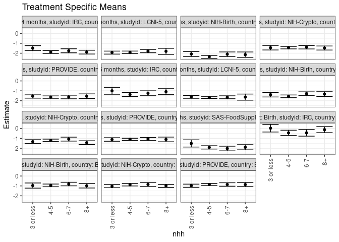

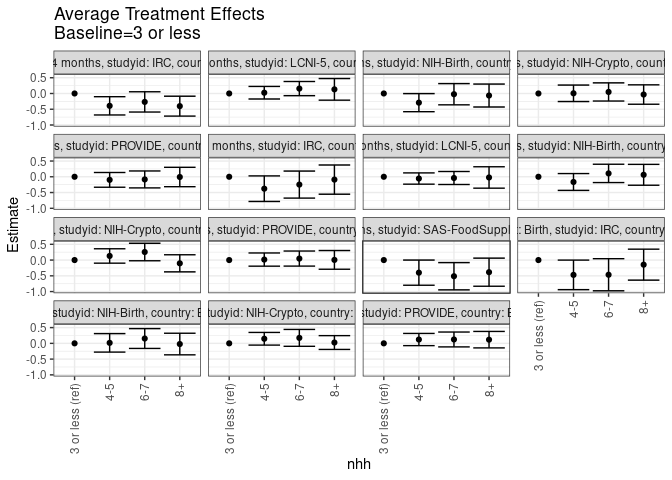

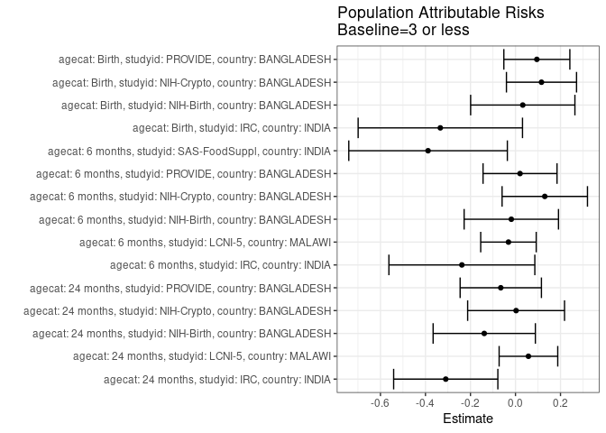

## Results Table

### Parameter: TSM

| agecat | studyid | country | intervention_level | baseline_level | estimate | ci_lower | ci_upper |
| --- | --- | --- | --- | --- | --- | --- | --- |
| Birth | IRC | INDIA | 3 or less | NA | 0.0259362 | -0.3581039 | 0.4099763 |
| Birth | IRC | INDIA | 4-5 | NA | -0.4441440 | -0.7136863 | -0.1746017 |
| Birth | IRC | INDIA | 6-7 | NA | -0.4399975 | -0.7743161 | -0.1056790 |
| Birth | IRC | INDIA | 8+ | NA | -0.1200700 | -0.4254758 | 0.1853358 |
| Birth | NIH-Birth | BANGLADESH | 3 or less | NA | -0.9633861 | -1.2225787 | -0.7041936 |
| Birth | NIH-Birth | BANGLADESH | 4-5 | NA | -0.9474330 | -1.0851150 | -0.8097509 |
| Birth | NIH-Birth | BANGLADESH | 6-7 | NA | -0.8104208 | -0.9901823 | -0.6306592 |
| Birth | NIH-Birth | BANGLADESH | 8+ | NA | -0.9851750 | -1.2092727 | -0.7610772 |
| Birth | NIH-Crypto | BANGLADESH | 3 or less | NA | -1.0250372 | -1.1833072 | -0.8667671 |
| Birth | NIH-Crypto | BANGLADESH | 4-5 | NA | -0.8791785 | -1.0038504 | -0.7545065 |
| Birth | NIH-Crypto | BANGLADESH | 6-7 | NA | -0.8514178 | -1.0673873 | -0.6354482 |
| Birth | NIH-Crypto | BANGLADESH | 8+ | NA | -0.9990532 | -1.1534560 | -0.8446503 |
| Birth | PROVIDE | BANGLADESH | 3 or less | NA | -0.9800228 | -1.1387988 | -0.8212467 |
| Birth | PROVIDE | BANGLADESH | 4-5 | NA | -0.8590272 | -0.9706458 | -0.7474086 |
| Birth | PROVIDE | BANGLADESH | 6-7 | NA | -0.8570672 | -1.0332134 | -0.6809210 |
| Birth | PROVIDE | BANGLADESH | 8+ | NA | -0.8634048 | -1.0711820 | -0.6556275 |
| 6 months | IRC | INDIA | 3 or less | NA | -0.9961711 | -1.3477227 | -0.6446196 |
| 6 months | IRC | INDIA | 4-5 | NA | -1.3742445 | -1.5780006 | -1.1704884 |
| 6 months | IRC | INDIA | 6-7 | NA | -1.2442882 | -1.4920641 | -0.9965123 |
| 6 months | IRC | INDIA | 8+ | NA | -1.0857178 | -1.3881397 | -0.7832959 |
| 6 months | LCNI-5 | MALAWI | 3 or less | NA | -1.6115017 | -1.7551847 | -1.4678186 |
| 6 months | LCNI-5 | MALAWI | 4-5 | NA | -1.6672706 | -1.7742463 | -1.5602950 |
| 6 months | LCNI-5 | MALAWI | 6-7 | NA | -1.6507125 | -1.7979723 | -1.5034527 |
| 6 months | LCNI-5 | MALAWI | 8+ | NA | -1.6335075 | -1.9417010 | -1.3253140 |
| 6 months | NIH-Birth | BANGLADESH | 3 or less | NA | -1.3888416 | -1.6195467 | -1.1581364 |
| 6 months | NIH-Birth | BANGLADESH | 4-5 | NA | -1.5539395 | -1.6907868 | -1.4170923 |
| 6 months | NIH-Birth | BANGLADESH | 6-7 | NA | -1.2820419 | -1.4618284 | -1.1022554 |
| 6 months | NIH-Birth | BANGLADESH | 8+ | NA | -1.3261598 | -1.5649704 | -1.0873493 |
| 6 months | NIH-Crypto | BANGLADESH | 3 or less | NA | -1.3288321 | -1.5244505 | -1.1332136 |
| 6 months | NIH-Crypto | BANGLADESH | 4-5 | NA | -1.1984982 | -1.3197608 | -1.0772355 |
| 6 months | NIH-Crypto | BANGLADESH | 6-7 | NA | -1.0733390 | -1.2714442 | -0.8752339 |
| 6 months | NIH-Crypto | BANGLADESH | 8+ | NA | -1.4322774 | -1.6230041 | -1.2415506 |
| 6 months | PROVIDE | BANGLADESH | 3 or less | NA | -1.1118904 | -1.2896902 | -0.9340906 |
| 6 months | PROVIDE | BANGLADESH | 4-5 | NA | -1.0963807 | -1.2059298 | -0.9868316 |
| 6 months | PROVIDE | BANGLADESH | 6-7 | NA | -1.0646404 | -1.2241054 | -0.9051753 |
| 6 months | PROVIDE | BANGLADESH | 8+ | NA | -1.1065073 | -1.3438580 | -0.8691566 |
| 6 months | SAS-FoodSuppl | INDIA | 3 or less | NA | -1.5102617 | -1.8731091 | -1.1474143 |
| 6 months | SAS-FoodSuppl | INDIA | 4-5 | NA | -1.9101199 | -2.0764759 | -1.7437640 |
| 6 months | SAS-FoodSuppl | INDIA | 6-7 | NA | -2.0234718 | -2.2595438 | -1.7873998 |
| 6 months | SAS-FoodSuppl | INDIA | 8+ | NA | -1.8951482 | -2.1546846 | -1.6356118 |
| 24 months | IRC | INDIA | 3 or less | NA | -1.4889312 | -1.7395393 | -1.2383230 |
| 24 months | IRC | INDIA | 4-5 | NA | -1.8807325 | -2.0256015 | -1.7358636 |
| 24 months | IRC | INDIA | 6-7 | NA | -1.7561543 | -1.9593239 | -1.5529846 |
| 24 months | IRC | INDIA | 8+ | NA | -1.8905452 | -2.0826642 | -1.6984261 |
| 24 months | LCNI-5 | MALAWI | 3 or less | NA | -1.9398204 | -2.0912484 | -1.7883925 |
| 24 months | LCNI-5 | MALAWI | 4-5 | NA | -1.9153994 | -2.0453175 | -1.7854813 |
| 24 months | LCNI-5 | MALAWI | 6-7 | NA | -1.7841416 | -1.9504638 | -1.6178195 |
| 24 months | LCNI-5 | MALAWI | 8+ | NA | -1.8086766 | -2.1162641 | -1.5010891 |
| 24 months | NIH-Birth | BANGLADESH | 3 or less | NA | -2.0802628 | -2.3290401 | -1.8314855 |
| 24 months | NIH-Birth | BANGLADESH | 4-5 | NA | -2.3714383 | -2.5181888 | -2.2246879 |
| 24 months | NIH-Birth | BANGLADESH | 6-7 | NA | -2.1034149 | -2.3336647 | -1.8731650 |
| 24 months | NIH-Birth | BANGLADESH | 8+ | NA | -2.1452510 | -2.4133636 | -1.8771384 |
| 24 months | NIH-Crypto | BANGLADESH | 3 or less | NA | -1.4439493 | -1.6736845 | -1.2142141 |
| 24 months | NIH-Crypto | BANGLADESH | 4-5 | NA | -1.4380168 | -1.5642155 | -1.3118181 |
| 24 months | NIH-Crypto | BANGLADESH | 6-7 | NA | -1.3953838 | -1.5697279 | -1.2210398 |
| 24 months | NIH-Crypto | BANGLADESH | 8+ | NA | -1.4769668 | -1.6815519 | -1.2723816 |
| 24 months | PROVIDE | BANGLADESH | 3 or less | NA | -1.5370796 | -1.7376890 | -1.3364702 |
| 24 months | PROVIDE | BANGLADESH | 4-5 | NA | -1.6347425 | -1.7567442 | -1.5127408 |
| 24 months | PROVIDE | BANGLADESH | 6-7 | NA | -1.6213632 | -1.8022305 | -1.4404958 |
| 24 months | PROVIDE | BANGLADESH | 8+ | NA | -1.5444774 | -1.7794888 | -1.3094661 |

### Parameter: E(Y)

| agecat | studyid | country | intervention_level | baseline_level | estimate | ci_lower | ci_upper |
| --- | --- | --- | --- | --- | --- | --- | --- |
| Birth | IRC | INDIA | NA | NA | -0.3080412 | -0.4687931 | -0.1472894 |
| Birth | NIH-Birth | BANGLADESH | NA | NA | -0.9310197 | -1.0197391 | -0.8423003 |
| Birth | NIH-Crypto | BANGLADESH | NA | NA | -0.9094945 | -0.9809370 | -0.8380521 |
| Birth | PROVIDE | BANGLADESH | NA | NA | -0.8851020 | -0.9601332 | -0.8100709 |
| 6 months | IRC | INDIA | NA | NA | -1.2344062 | -1.3658524 | -1.1029600 |
| 6 months | LCNI-5 | MALAWI | NA | NA | -1.6426961 | -1.7120603 | -1.5733318 |
| 6 months | NIH-Birth | BANGLADESH | NA | NA | -1.4073821 | -1.4960598 | -1.3187043 |
| 6 months | NIH-Crypto | BANGLADESH | NA | NA | -1.1986783 | -1.2700937 | -1.1272630 |
| 6 months | PROVIDE | BANGLADESH | NA | NA | -1.0916915 | -1.1661176 | -1.0172654 |
| 6 months | SAS-FoodSuppl | INDIA | NA | NA | -1.8986842 | -2.0118892 | -1.7854792 |
| 24 months | IRC | INDIA | NA | NA | -1.7987775 | -1.8923914 | -1.7051636 |
| 24 months | LCNI-5 | MALAWI | NA | NA | -1.8822648 | -1.9637218 | -1.8008078 |
| 24 months | NIH-Birth | BANGLADESH | NA | NA | -2.2190579 | -2.3217459 | -2.1163699 |
| 24 months | NIH-Crypto | BANGLADESH | NA | NA | -1.4412646 | -1.5249156 | -1.3576135 |
| 24 months | PROVIDE | BANGLADESH | NA | NA | -1.6024221 | -1.6857420 | -1.5191023 |

### Parameter: ATE

| agecat | studyid | country | intervention_level | baseline_level | estimate | ci_lower | ci_upper |
| --- | --- | --- | --- | --- | --- | --- | --- |
| Birth | IRC | INDIA | 3 or less | 3 or less | 0.0000000 | 0.0000000 | 0.0000000 |
| Birth | IRC | INDIA | 4-5 | 3 or less | -0.4700802 | -0.9395117 | -0.0006487 |
| Birth | IRC | INDIA | 6-7 | 3 or less | -0.4659337 | -0.9754493 | 0.0435819 |
| Birth | IRC | INDIA | 8+ | 3 or less | -0.1460062 | -0.6372354 | 0.3452230 |
| Birth | NIH-Birth | BANGLADESH | 3 or less | 3 or less | 0.0000000 | 0.0000000 | 0.0000000 |
| Birth | NIH-Birth | BANGLADESH | 4-5 | 3 or less | 0.0159532 | -0.2770966 | 0.3090030 |
| Birth | NIH-Birth | BANGLADESH | 6-7 | 3 or less | 0.1529653 | -0.1619802 | 0.4679109 |
| Birth | NIH-Birth | BANGLADESH | 8+ | 3 or less | -0.0217888 | -0.3641522 | 0.3205745 |
| Birth | NIH-Crypto | BANGLADESH | 3 or less | 3 or less | 0.0000000 | 0.0000000 | 0.0000000 |
| Birth | NIH-Crypto | BANGLADESH | 4-5 | 3 or less | 0.1458587 | -0.0552261 | 0.3469435 |
| Birth | NIH-Crypto | BANGLADESH | 6-7 | 3 or less | 0.1736194 | -0.0939555 | 0.4411943 |
| Birth | NIH-Crypto | BANGLADESH | 8+ | 3 or less | 0.0259840 | -0.1934553 | 0.2454233 |
| Birth | PROVIDE | BANGLADESH | 3 or less | 3 or less | 0.0000000 | 0.0000000 | 0.0000000 |
| Birth | PROVIDE | BANGLADESH | 4-5 | 3 or less | 0.1209956 | -0.0727878 | 0.3147790 |
| Birth | PROVIDE | BANGLADESH | 6-7 | 3 or less | 0.1229555 | -0.1134122 | 0.3593233 |
| Birth | PROVIDE | BANGLADESH | 8+ | 3 or less | 0.1166180 | -0.1444241 | 0.3776601 |
| 6 months | IRC | INDIA | 3 or less | 3 or less | 0.0000000 | 0.0000000 | 0.0000000 |
| 6 months | IRC | INDIA | 4-5 | 3 or less | -0.3780734 | -0.7833897 | 0.0272430 |
| 6 months | IRC | INDIA | 6-7 | 3 or less | -0.2481171 | -0.6773822 | 0.1811481 |
| 6 months | IRC | INDIA | 8+ | 3 or less | -0.0895467 | -0.5528283 | 0.3737350 |
| 6 months | LCNI-5 | MALAWI | 3 or less | 3 or less | 0.0000000 | 0.0000000 | 0.0000000 |
| 6 months | LCNI-5 | MALAWI | 4-5 | 3 or less | -0.0557689 | -0.2349878 | 0.1234499 |
| 6 months | LCNI-5 | MALAWI | 6-7 | 3 or less | -0.0392109 | -0.2450840 | 0.1666623 |
| 6 months | LCNI-5 | MALAWI | 8+ | 3 or less | -0.0220058 | -0.3620944 | 0.3180828 |
| 6 months | NIH-Birth | BANGLADESH | 3 or less | 3 or less | 0.0000000 | 0.0000000 | 0.0000000 |
| 6 months | NIH-Birth | BANGLADESH | 4-5 | 3 or less | -0.1650979 | -0.4323830 | 0.1021871 |
| 6 months | NIH-Birth | BANGLADESH | 6-7 | 3 or less | 0.1067997 | -0.1836812 | 0.3972806 |
| 6 months | NIH-Birth | BANGLADESH | 8+ | 3 or less | 0.0626817 | -0.2680725 | 0.3934359 |
| 6 months | NIH-Crypto | BANGLADESH | 3 or less | 3 or less | 0.0000000 | 0.0000000 | 0.0000000 |
| 6 months | NIH-Crypto | BANGLADESH | 4-5 | 3 or less | 0.1303339 | -0.0982384 | 0.3589062 |
| 6 months | NIH-Crypto | BANGLADESH | 6-7 | 3 or less | 0.2554930 | -0.0220093 | 0.5329953 |
| 6 months | NIH-Crypto | BANGLADESH | 8+ | 3 or less | -0.1034453 | -0.3748632 | 0.1679726 |
| 6 months | PROVIDE | BANGLADESH | 3 or less | 3 or less | 0.0000000 | 0.0000000 | 0.0000000 |
| 6 months | PROVIDE | BANGLADESH | 4-5 | 3 or less | 0.0155097 | -0.1935557 | 0.2245752 |
| 6 months | PROVIDE | BANGLADESH | 6-7 | 3 or less | 0.0472500 | -0.1917021 | 0.2862021 |
| 6 months | PROVIDE | BANGLADESH | 8+ | 3 or less | 0.0053831 | -0.2911459 | 0.3019122 |
| 6 months | SAS-FoodSuppl | INDIA | 3 or less | 3 or less | 0.0000000 | 0.0000000 | 0.0000000 |
| 6 months | SAS-FoodSuppl | INDIA | 4-5 | 3 or less | -0.3998582 | -0.7992581 | -0.0004584 |
| 6 months | SAS-FoodSuppl | INDIA | 6-7 | 3 or less | -0.5132101 | -0.9458922 | -0.0805281 |
| 6 months | SAS-FoodSuppl | INDIA | 8+ | 3 or less | -0.3848865 | -0.8309800 | 0.0612069 |
| 24 months | IRC | INDIA | 3 or less | 3 or less | 0.0000000 | 0.0000000 | 0.0000000 |
| 24 months | IRC | INDIA | 4-5 | 3 or less | -0.3918014 | -0.6810575 | -0.1025452 |
| 24 months | IRC | INDIA | 6-7 | 3 or less | -0.2672231 | -0.5889724 | 0.0545262 |
| 24 months | IRC | INDIA | 8+ | 3 or less | -0.4016140 | -0.7172900 | -0.0859381 |
| 24 months | LCNI-5 | MALAWI | 3 or less | 3 or less | 0.0000000 | 0.0000000 | 0.0000000 |
| 24 months | LCNI-5 | MALAWI | 4-5 | 3 or less | 0.0244210 | -0.1751865 | 0.2240285 |
| 24 months | LCNI-5 | MALAWI | 6-7 | 3 or less | 0.1556788 | -0.0693877 | 0.3807453 |
| 24 months | LCNI-5 | MALAWI | 8+ | 3 or less | 0.1311439 | -0.2118591 | 0.4741468 |
| 24 months | NIH-Birth | BANGLADESH | 3 or less | 3 or less | 0.0000000 | 0.0000000 | 0.0000000 |
| 24 months | NIH-Birth | BANGLADESH | 4-5 | 3 or less | -0.2911755 | -0.5784769 | -0.0038742 |
| 24 months | NIH-Birth | BANGLADESH | 6-7 | 3 or less | -0.0231521 | -0.3599898 | 0.3136856 |
| 24 months | NIH-Birth | BANGLADESH | 8+ | 3 or less | -0.0649882 | -0.4290750 | 0.2990986 |
| 24 months | NIH-Crypto | BANGLADESH | 3 or less | 3 or less | 0.0000000 | 0.0000000 | 0.0000000 |
| 24 months | NIH-Crypto | BANGLADESH | 4-5 | 3 or less | 0.0059325 | -0.2554551 | 0.2673200 |
| 24 months | NIH-Crypto | BANGLADESH | 6-7 | 3 or less | 0.0485655 | -0.2396490 | 0.3367799 |
| 24 months | NIH-Crypto | BANGLADESH | 8+ | 3 or less | -0.0330175 | -0.3405798 | 0.2745448 |
| 24 months | PROVIDE | BANGLADESH | 3 or less | 3 or less | 0.0000000 | 0.0000000 | 0.0000000 |
| 24 months | PROVIDE | BANGLADESH | 4-5 | 3 or less | -0.0976629 | -0.3312729 | 0.1359470 |
| 24 months | PROVIDE | BANGLADESH | 6-7 | 3 or less | -0.0842836 | -0.3535021 | 0.1849349 |
| 24 months | PROVIDE | BANGLADESH | 8+ | 3 or less | -0.0073979 | -0.3154547 | 0.3006590 |

### Parameter: PAR

| agecat | studyid | country | intervention_level | baseline_level | estimate | ci_lower | ci_upper |
| --- | --- | --- | --- | --- | --- | --- | --- |
| Birth | IRC | INDIA | 3 or less | NA | -0.3339774 | -0.6991475 | 0.0311926 |
| Birth | NIH-Birth | BANGLADESH | 3 or less | NA | 0.0323664 | -0.1993069 | 0.2640396 |
| Birth | NIH-Crypto | BANGLADESH | 3 or less | NA | 0.1155426 | -0.0401964 | 0.2712816 |
| Birth | PROVIDE | BANGLADESH | 3 or less | NA | 0.0949207 | -0.0517203 | 0.2415617 |
| 6 months | IRC | INDIA | 3 or less | NA | -0.2382351 | -0.5624072 | 0.0859371 |
| 6 months | LCNI-5 | MALAWI | 3 or less | NA | -0.0311944 | -0.1545146 | 0.0921257 |
| 6 months | NIH-Birth | BANGLADESH | 3 or less | NA | -0.0185405 | -0.2281740 | 0.1910930 |
| 6 months | NIH-Crypto | BANGLADESH | 3 or less | NA | 0.1301537 | -0.0595590 | 0.3198665 |
| 6 months | PROVIDE | BANGLADESH | 3 or less | NA | 0.0201989 | -0.1441253 | 0.1845231 |
| 6 months | SAS-FoodSuppl | INDIA | 3 or less | NA | -0.3884225 | -0.7407039 | -0.0361411 |
| 24 months | IRC | INDIA | 3 or less | NA | -0.3098463 | -0.5413582 | -0.0783345 |
| 24 months | LCNI-5 | MALAWI | 3 or less | NA | 0.0575556 | -0.0726627 | 0.1877739 |
| 24 months | NIH-Birth | BANGLADESH | 3 or less | NA | -0.1387951 | -0.3659490 | 0.0883589 |
| 24 months | NIH-Crypto | BANGLADESH | 3 or less | NA | 0.0026847 | -0.2125302 | 0.2178997 |
| 24 months | PROVIDE | BANGLADESH | 3 or less | NA | -0.0653426 | -0.2459410 | 0.1152559 |